# Markdown

## Краткое руководство

```
Абзацы создаются при помощи пустой строки. Если вокруг текста сверху и снизу есть пустые строки, то текст превращается в абзац.

Чтобы сделать перенос строки вместо абзаца,
нужно поставить два пробела в конце предыдущей строки.

Заголовки отмечаются диезом '#' в начале строки,от одного до шести. Например:

# Заголовок первого уровня #
## Заголовок h2
### Заголовок h3
#### Заголовок h4
##### Заголовок h5
###### Заголовок h6

В декоративных целях заголовки можно <<закрывать>> с обратной стороны.
```

### Списки

```
Для разметки неупорядоченных списков можно использовать или '*', или '-', или '+':

- элемент 1
- элемент 2
- элемент ...

Вложенные пункты создаются четырьмя пробелами перед маркером пункта:

    * элемент 1
    * элемент 2
        * вложенный элемент 2.1
        * вложенный элемент 2.2
    * элемент ...

Упорядоченный список:

    1. элемент 1
    2. элемент 2
        1. вложенный
        2. вложенный
    3. элемент 3
    4. Donec sit amet nisl. Aliquam semper ipsum sit amet velit. Suspendisse id sem consectetuer libero luctus adipiscing.
```

```python
import numpy as np
```

```python
vec = np.array([1,2,3])
vec.ndim # количество осей
```

```
1
```

```python
mat = np.array([[1,2,3],[4,5,6]])
mat.ndim
```

```
2
```

```python
vec.shape
```

```
(3,)
```

```python
mat.dtype.name
```

```
'int32'
```

```python
mat.itemsize
```

```
4
```

Создание массивов

```python
A = np.array([1,2,3])
A
```

```
array([1, 2, 3])
```

```python
A = np.array([1,2,3], dtype = float)
A
```

```
array([1., 2., 3.])
```

```python
B = np.array([(1,2,3),(4,5,6)])
B
```

```
array([[1, 2, 3],
       [4, 5, 6]])
```

Создание массивов специального вида при помощи zeros, ones, empty, identity:

```python
np.zeros((3,))
```

```
array([0., 0., 0.])
```

```python
np.ones((3,4))
```

```
array([[1., 1., 1., 1.],
       [1., 1., 1., 1.],
       [1., 1., 1., 1.]])
```

```python
np.identity(3)
```

```
array([[1., 0., 0.],
       [0., 1., 0.],
       [0., 0., 1.]])
```

```python
np.empty((2,5))
```

```
array([[6.23061763e-307, 1.02360867e-306, 1.22389163e-307,
        1.11260348e-306, 1.44635573e-307],
       [3.11525958e-307, 7.56602523e-307, 1.86918699e-306,
        8.01089062e-307, 2.22517402e-307]])
```

Создание последовательностей при помощи функций arange и linspace

```python
np.arange(2,20,3) # аналогично стандартной функции range python, правая граница не включается
```

```
array([ 2,  5,  8, 11, 14, 17])
```

```python
np.arange(2.5, 8.7, 0.9) # но может работать и с вещественными числами
```

```
array([2.5, 3.4, 4.3, 5.2, 6.1, 7. , 7.9])
```

```python
np.linspace(2,18,14) # правая граница включается (по умолчанию)
```

```
array([ 2.        ,  3.23076923,  4.46153846,  5.69230769,  6.92307692,
        8.15384615,  9.38461538, 10.61538462, 11.84615385, 13.07692308,
       14.30769231, 15.53846154, 16.76923077, 18.        ])
```

Для изменения размеров существуюего массива можно использовать функцией reshape:

```python
np.arange(9).reshape(3,3)
```

```
array([[0, 1, 2],
       [3, 4, 5],
       [6, 7, 8]])
```

Вместо значения длины масива по одному из измерений можно указать -1 - значение будет рассчитано автоматически:

```python
np.arange(8).reshape(2,-1)
```

```
array([[0, 1, 2, 3],
       [4, 5, 6, 7]])
```

Транспонирование существующего массива:

```python
C= np.arange(6).reshape(2,-1)
C
```

```
array([[0, 1, 2],
       [3, 4, 5]])
```

```python
C.T
```

```
array([[0, 3],
       [1, 4],
       [2, 5]])
```

Объединение существующих массивов по заданой оси:

```python
A = np.arange(6).reshape(2,-1)
np. hstack((A, A**2))
```

```
array([[ 0,  1,  2,  0,  1,  4],
       [ 3,  4,  5,  9, 16, 25]])
```

```python
np.vstack((A, A**2))
```

```
array([[ 0,  1,  2],
       [ 3,  4,  5],
       [ 0,  1,  4],
       [ 9, 16, 25]])
```

```python
np.concatenate((A,A**2), axis=1)
```

```
array([[ 0,  1,  2,  0,  1,  4],
       [ 3,  4,  5,  9, 16, 25]])
```

Повторение существующего массива

```python
a = np.arange(3)
np.tile(a,(2, 2))
```

```
array([[0, 1, 2, 0, 1, 2],
       [0, 1, 2, 0, 1, 2]])
```

```python
np.tile(a,(4,1))
```

```
array([[0, 1, 2],
       [0, 1, 2],
       [0, 1, 2],
       [0, 1, 2]])
```

Базовые операции

```python
A = np.arange(9).reshape(3, 3)
B = np.arange(1, 10).reshape(3, 3)
```

```python
print (A)
print (B)
```

```
[[0 1 2]
 [3 4 5]
 [6 7 8]]
[[1 2 3]
 [4 5 6]
 [7 8 9]]
```

```python
A + B
```

```
array([[ 1,  3,  5],
       [ 7,  9, 11],
       [13, 15, 17]])
```

```python
A * 1.0 / B
```

```
array([[0.        , 0.5       , 0.66666667],
       [0.75      , 0.8       , 0.83333333],
       [0.85714286, 0.875     , 0.88888889]])
```

```python
A + 1
```

```
array([[1, 2, 3],
       [4, 5, 6],
       [7, 8, 9]])
```

```python
3 * A
```

```
array([[ 0,  3,  6],
       [ 9, 12, 15],
       [18, 21, 24]])
```

```python
A ** 2
```

```
array([[ 0,  1,  4],
       [ 9, 16, 25],
       [36, 49, 64]], dtype=int32)
```

Поэлементное умножение массивов:

```python
A * B
```

```
array([[ 0,  2,  6],
       [12, 20, 30],
       [42, 56, 72]])
```

Для выполнения матричного умножения необходимо использовать функцию dot:

```python
A.dot(B)
```

```
array([[ 18,  21,  24],
       [ 54,  66,  78],
       [ 90, 111, 132]])
```

```python
np.tile(np.arange(0,40,10),(3,1)).T + np.array([0,1,2])
```

```
array([[ 0,  1,  2],
       [10, 11, 12],
       [20, 21, 22],
       [30, 31, 32]])
```

Универсальные функции (sin, cos, exp и т.д.) также применяются поэлементно:

```python
np.exp(A)
```

```
array([[1.00000000e+00, 2.71828183e+00, 7.38905610e+00],
       [2.00855369e+01, 5.45981500e+01, 1.48413159e+02],
       [4.03428793e+02, 1.09663316e+03, 2.98095799e+03]])
```

Некоторые операции над массивами:

```python
A
```

```
array([[0, 1, 2],
       [3, 4, 5],
       [6, 7, 8]])
```

```python
A.min()
```

```
0
```

```python
A.max(axis = 0)
```

```
array([6, 7, 8])
```

```python
A.sum(axis = 1)
```

```
array([ 3, 12, 21])
```

Индексация

```python
a = np.arange(10)
a
```

[output not shown]

```python
a[2:5]
```

[output not shown]

```python
a[3:8:2]
```

[output not shown]

```python
A = np.arange(81).reshape(9,-1)
A
```

[output not shown]

```python
A[2:4]
```

[output not shown]

```python
A[:, 2:4]
```

[output not shown]

```python
A[2:4,2:4]
```

[output not shown]

```python
A[-1]
```

[output not shown]

Также может использоваться индексация при помощи списков индексов(по каждой из осей):

```python
A = np.arange(81).reshape(9,-1)
A
```

[output not shown]

```python
A[[2,4,5],[0,1,3]]
```

[output not shown]

Может также применяться логическая индексация (при помощи логичеких массивов):

```python
A = np.arange(11)
A
```

[output not shown]

```python
A[A % 5 !=3]
```

[output not shown]

```python
A[np.logical_and(A !=7, A % 5 !=3)] # также можно использовать логичексие операции
```

[output not shown]

Причина использовать NumPy-скорость. Посчитаем сумму поэлементных произведений 2 больших векторов:

```python
import time
import numpy as np

A_quick_arr = np.random.normal(size = (1000000,))
B_quick_arr = np.random.normal(size = (1000000,))

A_slow_list, B_slow_list = list(A_quick_arr), list(B_quick_arr)
```

```python
start = time.clock()
ans = 0
for i in range(len(A_slow_list)):
    ans += A_slow_list[i] * B_slow_list[i]
print(time.clock() - start) # Время выполнения в секундах
```

0.310231

```python
start = time.process_time()
ans = sum([A_slow_list[i] * B_slow_list[i] for i in range(1000000)])
print(time.process_time() - start)
```

0.322319

```python
start = time.process_time()
ans = np.sum(A_quick_arr * B_quick_arr)
print(time.process_time() - start)
```

0.005845

```python
start = time.process_time()
ans = A_quick_arr.dot(B_quick_arr)
print(time.process_time() - start)
```

0.003035

Pandas Series:

```python
import pandas as pd
my_series = pd.Series([5,6,7,8,9,10])
my_series
```

```
0     5
1     6
2     7
3     8
4     9
5    10
dtype: int64
```

```python
my_series.index
```

```
RangeIndex(start=0, stop=6, step=1)
```

```python
my_series.values
```

```
array([ 5,  6,  7,  8,  9, 10], dtype=int64)
```

```python
my_series[4]
```

```
9
```

Индексы можно задавать явно:

```python
my_series2 = pd.Series([5,6,7,8,9,10], index=['a','b','c','d','e','f'])
my_series2['f']
```

```
10
```

Делать выборку по нескольким индексам и осуществлять групповое присваивание:

```python
my_series2[['a','b','f']]
```

```
a     5
b     6
f    10
dtype: int64
```

```python
my_series2[['a','b','f']] = 0
my_series2
```

```
a    0
b    0
c    7
d    8
e    9
f    0
dtype: int64
```

Фильтрация series, мат.операции и т.д.

```python
my_series2[my_series2 > 0]
```

```
c    7
d    8
e    9
dtype: int64
```

```python
my_series2[my_series2 > 0] * 2
```

```
c    14
d    16
e    18
dtype: int64
```

```python
my_series3 = pd.Series({'a':5,'b':6,'c':7,'d':8})
my_series3
```

```
a    5
b    6
c    7
d    8
dtype: int64
```

У оъекта series и его индекса есть атрибут name, задающий имя объекту и индексу соотвественно.

```python
my_series3.name = 'numbers'
my_series3.index.name = 'letters'
my_series3
```

```
letters
a    5
b    6
c    7
d    8
Name: numbers, dtype: int64
```

Индекс можно менять, присвоив список атрибуту index объекта series

```python
my_series3.index = ['A','B','C','D']
my_series3
```

```
A    5
B    6
C    7
D    8
Name: numbers, dtype: int64
```

DataFrame

```python
df = pd.DataFrame({
...     'country':['Kazakhstan','Russia','Belarus','Ukraine'],
...     'population':[17.04, 143.5, 9.5, 45.5],
...     'square':[2724902, 17125191, 207600, 603628]
... })
df
```

|  | country | population | square |
| --- | --- | --- | --- |
| 0 | Kazakhstan | 17.04 | 2724902 |
| 1 | Russia | 143.50 | 17125191 |
| 2 | Belarus | 9.50 | 207600 |
| 3 | Ukraine | 45.50 | 603628 |

Чтобы убедиться, что столбец в DataFrame это series, извлекаем любой:

```python
df['country']
```

```
0    Kazakhstan
1        Russia
2       Belarus
3       Ukraine
Name: country, dtype: object
```

```python
df.columns
```

```
Index(['country', 'population', 'square'], dtype='object')
```

```python
df.index
```

```
RangeIndex(start=0, stop=4, step=1)
```

```python
df = pd.DataFrame({
...     'country':['Kazakhstan','Russia','Belarus','Ukraine'],
...     'population':[17.04, 143.5, 9.5, 45.5],
...     'square':[2724902, 17125191, 207600, 603628]
... }, index=['KZ','RU','BY','UA'])
df
```

|  | country | population | square |
| --- | --- | --- | --- |
| KZ | Kazakhstan | 17.04 | 2724902 |
| RU | Russia | 143.50 | 17125191 |
| BY | Belarus | 9.50 | 207600 |
| UA | Ukraine | 45.50 | 603628 |

```python
df.index=['KZ','RU','BY','UA']
df.index.name = 'Country Code'
df
```

| Country Code | country | population | square |
| --- | --- | --- | --- |
| KZ | Kazakhstan | 17.04 | 2724902 |
| RU | Russia | 143.50 | 17125191 |
| BY | Belarus | 9.50 | 207600 |
| UA | Ukraine | 45.50 | 603628 |

```python
df['country']
```

```
Country Code
KZ    Kazakhstan
RU        Russia
BY       Belarus
UA       Ukraine
Name: country, dtype: object
```

Доступ к строкам по индексу возможен несколькими способами:  
.loc-используется для доступа по строковой метке  
.iloc-используется для доступа по числовому значению

```python
df.loc['KZ']
```

```
country       Kazakhstan
population         17.04
square           2724902
Name: KZ, dtype: object
```

```python
df.iloc[0]
```

```
country       Kazakhstan
population         17.04
square           2724902
Name: KZ, dtype: object
```

Можно делать выбоку по индексу и интересующим колонкам:

```python
df.loc[['KZ','RU'], 'population']
```

```
Country Code
KZ     17.04
RU    143.50
Name: population, dtype: float64
```

```python
df.loc['KZ':'BY',:]
```

| Country Code | country | population | square |
| --- | --- | --- | --- |
| KZ | Kazakhstan | 17.04 | 2724902 |
| RU | Russia | 143.50 | 17125191 |
| BY | Belarus | 9.50 | 207600 |

Филтровать DataFrame с помощью т.н. булевых массивов:

```python
df[df.population > 10][['country','square']]
```

| Country Code | country | square |
| --- | --- | --- |
| KZ | Kazakhstan | 2724902 |
| RU | Russia | 17125191 |
| UA | Ukraine | 603628 |

```python
df.reset_index()
```

|  | Country Code | country | population | square |
| --- | --- | --- | --- | --- |
| 0 | KZ | Kazakhstan | 17.04 | 2724902 |
| 1 | RU | Russia | 143.50 | 17125191 |
| 2 | BY | Belarus | 9.50 | 207600 |
| 3 | UA | Ukraine | 45.50 | 603628 |

Pandas при операциях над DataFrame, возвращает новый объект DataFrame  
Добавим новый столбец, в котором население поделим на площадь страны, получив тем самым плотность:

```python
df['density'] = df['population']/df['square']*1000000
df
```

| Country Code | country | population | square | density |
| --- | --- | --- | --- | --- |
| KZ | Kazakhstan | 17.04 | 2724902 | 6.253436 |
| RU | Russia | 143.50 | 17125191 | 8.379469 |
| BY | Belarus | 9.50 | 207600 | 45.761079 |
| UA | Ukraine | 45.50 | 603628 | 75.377550 |

```python
df.drop(['density'], axis='columns')
```

| Country Code | country | population | square |
| --- | --- | --- | --- |
| KZ | Kazakhstan | 17.04 | 2724902 |
| RU | Russia | 143.50 | 17125191 |
| BY | Belarus | 9.50 | 207600 |
| UA | Ukraine | 45.50 | 603628 |

```python
df=df.rename(columns={'Country Code': 'country_code'})
df
```

| Country Code | country | population | square | density |
| --- | --- | --- | --- | --- |
| KZ | Kazakhstan | 17.04 | 2724902 | 6.253436 |
| RU | Russia | 143.50 | 17125191 | 8.379469 |
| BY | Belarus | 9.50 | 207600 | 45.761079 |
| UA | Ukraine | 45.50 | 603628 | 75.377550 |

Группировка и агрегирование в pandas

```python
titanic_df = pd.read_csv('titanic.csv')
print(titanic_df.head())
```

```
   PassengerId  Survived  Pclass  \
0            1         0       3
1            2         1       1
2            3         1       3
3            4         1       1
4            5         0       3

                                                Name     Sex   Age  SibSp  \
0                            Braund, Mr. Owen Harris    male  22.0      1
1  Cumings, Mrs. John Bradley (Florence Briggs Th...  female  38.0      1
2                             Heikkinen, Miss. Laina  female  26.0      0
3       Futrelle, Mrs. Jacques Heath (Lily May Peel)  female  35.0      1
4                           Allen, Mr. William Henry    male  35.0      0

   Parch            Ticket     Fare Cabin Embarked
0      0         A/5 21171   7.2500   NaN        S
1      0          PC 17599  71.2833   C85        C
2      0  STON/O2. 3101282   7.9250   NaN        S
3      0            113803  53.1000  C123        S
4      0            373450   8.0500   NaN        S
```

Необходимо подсчитать, сколько женщин и мужчин выжило, а сколько нет. В этом нам помжет метод .groupby.

```python
print(titanic_df.groupby(['Sex', 'Survived'])['PassengerId'].count())
```

```
Sex     Survived
female  0            81
        1           233
male    0           468
        1           109
Name: PassengerId, dtype: int64
```

А теперь проанализируем в разрезе класса каюты:

```python
print(titanic_df.groupby(['Pclass', 'Survived'])['PassengerId'].count())
```

```
Pclass  Survived
1       0            80
        1           136
2       0            97
        1            87
3       0           372
        1           119
Name: PassengerId, dtype: int64
```

```python
import pandas as pd
%matplotlib inline
```

```python
pass_data = pd.read_csv('titanic.csv')
pass_data
```

|  | PassengerId | Survived | Pclass | Name | Sex | Age | SibSp | Parch | Ticket | Fare | Cabin | Embarked |
| --- | --- | --- | --- | --- | --- | --- | --- | --- | --- | --- | --- | --- |
| 0 | 1 | 0 | 3 | Braund, Mr. Owen Harris | male | 22.0 | 1 | 0 | A/5 21171 | 7.2500 | NaN | S |
| 1 | 2 | 1 | 1 | Cumings, Mrs. John Bradley (Florence Briggs Th... | female | 38.0 | 1 | 0 | PC 17599 | 71.2833 | C85 | C |
| 2 | 3 | 1 | 3 | Heikkinen, Miss. Laina | female | 26.0 | 0 | 0 | STON/O2. 3101282 | 7.9250 | NaN | S |
| 3 | 4 | 1 | 1 | Futrelle, Mrs. Jacques Heath (Lily May Peel) | female | 35.0 | 1 | 0 | 113803 | 53.1000 | C123 | S |
| 4 | 5 | 0 | 3 | Allen, Mr. William Henry | male | 35.0 | 0 | 0 | 373450 | 8.0500 | NaN | S |
| ... | ... | ... | ... | ... | ... | ... | ... | ... | ... | ... | ... | ... |
| 886 | 887 | 0 | 2 | Montvila, Rev. Juozas | male | 27.0 | 0 | 0 | 211536 | 13.0000 | NaN | S |
| 887 | 888 | 1 | 1 | Graham, Miss. Margaret Edith | female | 19.0 | 0 | 0 | 112053 | 30.0000 | B42 | S |
| 888 | 889 | 0 | 3 | Johnston, Miss. Catherine Helen "Carrie" | female | NaN | 1 | 2 | W./C. 6607 | 23.4500 | NaN | S |
| 889 | 890 | 1 | 1 | Behr, Mr. Karl Howell | male | 26.0 | 0 | 0 | 111369 | 30.0000 | C148 | C |
| 890 | 891 | 0 | 3 | Dooley, Mr. Patrick | male | 32.0 | 0 | 0 | 370376 | 7.7500 | NaN | Q |

891 rows × 12 columns

```python
pass_data.head(3)
```

|  | PassengerId | Survived | Pclass | Name | Sex | Age | SibSp | Parch | Ticket | Fare | Cabin | Embarked |
| --- | --- | --- | --- | --- | --- | --- | --- | --- | --- | --- | --- | --- |
| 0 | 1 | 0 | 3 | Braund, Mr. Owen Harris | male | 22.0 | 1 | 0 | A/5 21171 | 7.2500 | NaN | S |
| 1 | 2 | 1 | 1 | Cumings, Mrs. John Bradley (Florence Briggs Th... | female | 38.0 | 1 | 0 | PC 17599 | 71.2833 | C85 | C |
| 2 | 3 | 1 | 3 | Heikkinen, Miss. Laina | female | 26.0 | 0 | 0 | STON/O2. 3101282 | 7.9250 | NaN | S |

```python
pass_data.columns
```

```
Index(['PassengerId', 'Survived', 'Pclass', 'Name', 'Sex', 'Age', 'SibSp',
       'Parch', 'Ticket', 'Fare', 'Cabin', 'Embarked'],
      dtype='object')
```

```python
pass_data[2:5]
```

|  | PassengerId | Survived | Pclass | Name | Sex | Age | SibSp | Parch | Ticket | Fare | Cabin | Embarked |
| --- | --- | --- | --- | --- | --- | --- | --- | --- | --- | --- | --- | --- |
| 2 | 3 | 1 | 3 | Heikkinen, Miss. Laina | female | 26.0 | 0 | 0 | STON/O2. 3101282 | 7.925 | NaN | S |
| 3 | 4 | 1 | 1 | Futrelle, Mrs. Jacques Heath (Lily May Peel) | female | 35.0 | 1 | 0 | 113803 | 53.100 | C123 | S |
| 4 | 5 | 0 | 3 | Allen, Mr. William Henry | male | 35.0 | 0 | 0 | 373450 | 8.050 | NaN | S |

```python
pass_data.iloc[1:5,[1,3]]
```

|  | Survived | Name |
| --- | --- | --- |
| 1 | 1 | Cumings, Mrs. John Bradley (Florence Briggs Th... |
| 2 | 1 | Heikkinen, Miss. Laina |
| 3 | 1 | Futrelle, Mrs. Jacques Heath (Lily May Peel) |
| 4 | 0 | Allen, Mr. William Henry |

```python
pass_data['Name'].head()
```

```
0                              Braund, Mr. Owen Harris
1    Cumings, Mrs. John Bradley (Florence Briggs Th...
2                               Heikkinen, Miss. Laina
3         Futrelle, Mrs. Jacques Heath (Lily May Peel)
4                             Allen, Mr. William Henry
Name: Name, dtype: object
```

```python
pass_data[['Name', 'Sex', 'Parch']].head()
```

|  | Name | Sex | Parch |
| --- | --- | --- | --- |
| 0 | Braund, Mr. Owen Harris | male | 0 |
| 1 | Cumings, Mrs. John Bradley (Florence Briggs Th... | female | 0 |
| 2 | Heikkinen, Miss. Laina | female | 0 |
| 3 | Futrelle, Mrs. Jacques Heath (Lily May Peel) | female | 0 |
| 4 | Allen, Mr. William Henry | male | 0 |

```python
pass_data[pass_data['Sex'] == 'female'].head() # Женщины на борту
```

|  | PassengerId | Survived | Pclass | Name | Sex | Age | SibSp | Parch | Ticket | Fare | Cabin | Embarked |
| --- | --- | --- | --- | --- | --- | --- | --- | --- | --- | --- | --- | --- |
| 1 | 2 | 1 | 1 | Cumings, Mrs. John Bradley (Florence Briggs Th... | female | 38.0 | 1 | 0 | PC 17599 | 71.2833 | C85 | C |
| 2 | 3 | 1 | 3 | Heikkinen, Miss. Laina | female | 26.0 | 0 | 0 | STON/O2. 3101282 | 7.9250 | NaN | S |
| 3 | 4 | 1 | 1 | Futrelle, Mrs. Jacques Heath (Lily May Peel) | female | 35.0 | 1 | 0 | 113803 | 53.1000 | C123 | S |
| 8 | 9 | 1 | 3 | Johnson, Mrs. Oscar W (Elisabeth Vilhelmina Berg) | female | 27.0 | 0 | 2 | 347742 | 11.1333 | NaN | S |
| 9 | 10 | 1 | 2 | Nasser, Mrs. Nicholas (Adele Achem) | female | 14.0 | 1 | 0 | 237736 | 30.0708 | NaN | C |

```python
pass_data[(pass_data['Sex'] == 'female') & (pass_data['Age'] >= 60) | (pass_data['Sex'] == 'male')].head()
```

|  | PassengerId | Survived | Pclass | Name | Sex | Age | SibSp | Parch | Ticket | Fare | Cabin | Embarked |
| --- | --- | --- | --- | --- | --- | --- | --- | --- | --- | --- | --- | --- |
| 0 | 1 | 0 | 3 | Braund, Mr. Owen Harris | male | 22.0 | 1 | 0 | A/5 21171 | 7.2500 | NaN | S |
| 4 | 5 | 0 | 3 | Allen, Mr. William Henry | male | 35.0 | 0 | 0 | 373450 | 8.0500 | NaN | S |
| 5 | 6 | 0 | 3 | Moran, Mr. James | male | NaN | 0 | 0 | 330877 | 8.4583 | NaN | Q |
| 6 | 7 | 0 | 1 | McCarthy, Mr. Timothy J | male | 54.0 | 0 | 0 | 17463 | 51.8625 | E46 | S |
| 7 | 8 | 0 | 3 | Palsson, Master. Gosta Leonard | male | 2.0 | 3 | 1 | 349909 | 21.0750 | NaN | S |

```python
pass_data[
    (pass_data.Sex == 'female') &
    (pass_data.Age > 18) &
    (pass_data.Age < 25) &
    (pass_data.SibSp == 0) &
    (pass_data.Parch == 0)].shape
```

```
(25, 12)
```

```python
import matplotlib.pyplot as plt
```

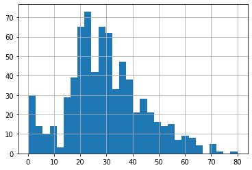

```python
pass_data.Age.hist(bins=30)
```

Редактрование DataFrame переименование признаков

```python
pass_data.rename(columns={'Sex': 'sex'}, inplace=True)
pass_data
```

|  | PassengerId | Survived | Pclass | Name | sex | Age | SibSp | Parch | Ticket | Fare | Cabin | Embarked |
| --- | --- | --- | --- | --- | --- | --- | --- | --- | --- | --- | --- | --- |
| 0 | 1 | 0 | 3 | Braund, Mr. Owen Harris | male | 22.0 | 1 | 0 | A/5 21171 | 7.2500 | NaN | S |
| 1 | 2 | 1 | 1 | Cumings, Mrs. John Bradley (Florence Briggs Th... | female | 38.0 | 1 | 0 | PC 17599 | 71.2833 | C85 | C |
| 2 | 3 | 1 | 3 | Heikkinen, Miss. Laina | female | 26.0 | 0 | 0 | STON/O2. 3101282 | 7.9250 | NaN | S |
| 3 | 4 | 1 | 1 | Futrelle, Mrs. Jacques Heath (Lily May Peel) | female | 35.0 | 1 | 0 | 113803 | 53.1000 | C123 | S |
| 4 | 5 | 0 | 3 | Allen, Mr. William Henry | male | 35.0 | 0 | 0 | 373450 | 8.0500 | NaN | S |
| ... | ... | ... | ... | ... | ... | ... | ... | ... | ... | ... | ... | ... |
| 886 | 887 | 0 | 2 | Montvila, Rev. Juozas | male | 27.0 | 0 | 0 | 211536 | 13.0000 | NaN | S |
| 887 | 888 | 1 | 1 | Graham, Miss. Margaret Edith | female | 19.0 | 0 | 0 | 112053 | 30.0000 | B42 | S |
| 888 | 889 | 0 | 3 | Johnston, Miss. Catherine Helen "Carrie" | female | NaN | 1 | 2 | W./C. 6607 | 23.4500 | NaN | S |
| 889 | 890 | 1 | 1 | Behr, Mr. Karl Howell | male | 26.0 | 0 | 0 | 111369 | 30.0000 | C148 | C |
| 890 | 891 | 0 | 3 | Dooley, Mr. Patrick | male | 32.0 | 0 | 0 | 370376 | 7.7500 | NaN | Q |

891 rows × 12 columns

```python
pass_data.columns = [i.lower() for i in pass_data.columns]
def get_last_name(name: str = ''):
    return name.split(',')[0].strip()

last_names = pass_data['name'].apply(get_last_name)
last_names.head()
```

```
0       Braund
1      Cumings
2    Heikkinen
3     Futrelle
4        Allen
Name: name, dtype: object
```

Добавление признака

```python
pass_data['last_name'] = last_names
pass_data.head()
```

|  | passengerid | survived | pclass | name | sex | age | sibsp | parch | ticket | fare | cabin | embarked | last_name |
| --- | --- | --- | --- | --- | --- | --- | --- | --- | --- | --- | --- | --- | --- |
| 0 | 1 | 0 | 3 | Braund, Mr. Owen Harris | male | 22.0 | 1 | 0 | A/5 21171 | 7.2500 | NaN | S | Braund |
| 1 | 2 | 1 | 1 | Cumings, Mrs. John Bradley (Florence Briggs Th... | female | 38.0 | 1 | 0 | PC 17599 | 71.2833 | C85 | C | Cumings |
| 2 | 3 | 1 | 3 | Heikkinen, Miss. Laina | female | 26.0 | 0 | 0 | STON/O2. 3101282 | 7.9250 | NaN | S | Heikkinen |
| 3 | 4 | 1 | 1 | Futrelle, Mrs. Jacques Heath (Lily May Peel) | female | 35.0 | 1 | 0 | 113803 | 53.1000 | C123 | S | Futrelle |
| 4 | 5 | 0 | 3 | Allen, Mr. William Henry | male | 35.0 | 0 | 0 | 373450 | 8.0500 | NaN | S | Allen |

Удаление признака:

```python
pass_data.drop('last_name', axis=1, inplace=True)
pass_data.head()
```

|  | passengerid | survived | pclass | name | sex | age | sibsp | parch | ticket | fare | cabin | embarked |
| --- | --- | --- | --- | --- | --- | --- | --- | --- | --- | --- | --- | --- |
| 0 | 1 | 0 | 3 | Braund, Mr. Owen Harris | male | 22.0 | 1 | 0 | A/5 21171 | 7.2500 | NaN | S |
| 1 | 2 | 1 | 1 | Cumings, Mrs. John Bradley (Florence Briggs Th... | female | 38.0 | 1 | 0 | PC 17599 | 71.2833 | C85 | C |
| 2 | 3 | 1 | 3 | Heikkinen, Miss. Laina | female | 26.0 | 0 | 0 | STON/O2. 3101282 | 7.9250 | NaN | S |
| 3 | 4 | 1 | 1 | Futrelle, Mrs. Jacques Heath (Lily May Peel) | female | 35.0 | 1 | 0 | 113803 | 53.1000 | C123 | S |
| 4 | 5 | 0 | 3 | Allen, Mr. William Henry | male | 35.0 | 0 | 0 | 373450 | 8.0500 | NaN | S |

```python
pass_data[pass_data['sibsp'].notnull()].head()
```

|  | passengerid | survived | pclass | name | sex | age | sibsp | parch | ticket | fare | cabin | embarked |
| --- | --- | --- | --- | --- | --- | --- | --- | --- | --- | --- | --- | --- |
| 0 | 1 | 0 | 3 | Braund, Mr. Owen Harris | male | 22.0 | 1 | 0 | A/5 21171 | 7.2500 | NaN | S |
| 1 | 2 | 1 | 1 | Cumings, Mrs. John Bradley (Florence Briggs Th... | female | 38.0 | 1 | 0 | PC 17599 | 71.2833 | C85 | C |
| 2 | 3 | 1 | 3 | Heikkinen, Miss. Laina | female | 26.0 | 0 | 0 | STON/O2. 3101282 | 7.9250 | NaN | S |
| 3 | 4 | 1 | 1 | Futrelle, Mrs. Jacques Heath (Lily May Peel) | female | 35.0 | 1 | 0 | 113803 | 53.1000 | C123 | S |
| 4 | 5 | 0 | 3 | Allen, Mr. William Henry | male | 35.0 | 0 | 0 | 373450 | 8.0500 | NaN | S |

```python
pass_data.sort_values(by=['pclass', 'fare'], ascending=True).head()
```

|  | passengerid | survived | pclass | name | sex | age | sibsp | parch | ticket | fare | cabin | embarked |
| --- | --- | --- | --- | --- | --- | --- | --- | --- | --- | --- | --- | --- |
| 263 | 264 | 0 | 1 | Harrison, Mr. William | male | 40.0 | 0 | 0 | 112059 | 0.0 | B94 | S |
| 633 | 634 | 0 | 1 | Parr, Mr. William Henry Marsh | male | NaN | 0 | 0 | 112052 | 0.0 | NaN | S |
| 806 | 807 | 0 | 1 | Andrews, Mr. Thomas Jr | male | 39.0 | 0 | 0 | 112050 | 0.0 | A36 | S |
| 815 | 816 | 0 | 1 | Fry, Mr. Richard | male | NaN | 0 | 0 | 112058 | 0.0 | B102 | S |
| 822 | 823 | 0 | 1 | Reuchlin, Jonkheer. John George | male | 38.0 | 0 | 0 | 19972 | 0.0 | NaN | S |

```python
pass_data.sort_values(by=['pclass', 'fare'], ascending=[True, False]).head()
```

|  | passengerid | survived | pclass | name | sex | age | sibsp | parch | ticket | fare | cabin | embarked |
| --- | --- | --- | --- | --- | --- | --- | --- | --- | --- | --- | --- | --- |
| 258 | 259 | 1 | 1 | Ward, Miss. Anna | female | 35.0 | 0 | 0 | PC 17755 | 512.3292 | NaN | C |
| 679 | 680 | 1 | 1 | Cardeza, Mr. Thomas Drake Martinez | male | 36.0 | 0 | 1 | PC 17755 | 512.3292 | B51 B53 B55 | C |
| 737 | 738 | 1 | 1 | Lesurer, Mr. Gustave J | male | 35.0 | 0 | 0 | PC 17755 | 512.3292 | B101 | C |
| 27 | 28 | 0 | 1 | Fortune, Mr. Charles Alexander | male | 19.0 | 3 | 2 | 19950 | 263.0000 | C23 C25 C27 | S |
| 88 | 89 | 1 | 1 | Fortune, Miss. Mabel Helen | female | 23.0 | 3 | 2 | 19950 | 263.0000 | C23 C25 C27 | S |

Группировка данных

```python
pass_data.groupby('sex')
```

```
<pandas.core.groupby.generic.DataFrameGroupBy object at 0x0000024567AD2BE0>
```

```python
pass_data.groupby('sex')['pclass'].value_counts()
```

```
sex     pclass
female  3         144
        1          94
        2          76
male    3         347
        1         122
        2         108
Name: pclass, dtype: int64
```

```python
pass_data.groupby('pclass')['fare'].describe()
```

| pclass | count | mean | std | min | 25% | 50% | 75% | max |
| --- | --- | --- | --- | --- | --- | --- | --- | --- |
| 1 | 216.0 | 84.154687 | 78.380373 | 0.0 | 30.92395 | 60.2875 | 93.5 | 512.3292 |
| 2 | 184.0 | 20.662183 | 13.417399 | 0.0 | 13.00000 | 14.2500 | 26.0 | 73.5000 |
| 3 | 491.0 | 13.675550 | 11.778142 | 0.0 | 7.75000 | 8.0500 | 15.5 | 69.5500 |

```python
pass_data.groupby('sex')['age'].mean()
```

```
sex
female    27.915709
male      30.726645
Name: age, dtype: float64
```

```python
pass_data.groupby('sex')['survived'].mean()
```

```
sex
female    0.742038
male      0.188908
Name: survived, dtype: float64
```

```python
pass_data.groupby('pclass')['survived'].mean()
```

```
pclass
1    0.629630
2    0.472826
3    0.242363
Name: survived, dtype: float64
```

```python
pass_data.groupby('sex', as_index=False)['survived'].mean()
```

|  | sex | survived |
| --- | --- | --- |
| 0 | female | 0.742038 |
| 1 | male | 0.188908 |